# R Notebook

```r
#Load libraries
library("readxl")
library(factoextra)
library(caret)
library(lime) #Explain multiclass random forest
library(rpart)
library(cluster)
library(rpart.plot)
library(psych)
options(ztable.type="html")
library("utiml") #Multilabel classification
```

Intro) Dans les jeux Pokemon, les pokémons sont regroupés dans ce que l’on appelle des “groupes d’oeufs”. Ces groupes déterminent quels pokemons peuvent se reproduire entre eux et sont par conséquent similaire à la notion de “genre animal”. Par exemple, le lion et le tigre font parti du même genre et peuve ainsi donner naissance à des hybrides.

Dans ce notebook, on essaye de construire un modèle de prédiction d’appartenance ou non des pokémons aux différents groupes d’oeufs sur la base de plusieurs variables.

Ces variables sont notamment : les types des pokemons, leurs caractéristiques physiques (taille, poids, couleur, physionomie) ainsi que des variables extraites du clustering des signals audios des cris des pokemons (voir notebook SBD CLUSTERING.Rmd). En effet, étant donné que les cris sont caractéristiques des espèces, il semble logique de penser que ces données puissent aider à identifier le groupe d’oeuf.

```r
#Read Excel file with data
data <- read_excel("data_clean.xlsx")
data <- as.data.frame(data)
```

1. On visualise les correlations entre les donnes, notamment pour avoir un apercu des variables jouant sur l’appartenance ou non à un groupe d’oeuf pour un pokémon donné.

```r
data_2 = data[-c(1:3)]

code = function(x) {
  if (x > 0 )
    return (1)
  else
    return (0)
}

Correlations = function(data, col) {
  #Corrélations et choix du col
  corr = as.data.frame(cor(data))
  col_choisit = corr[c(col)]

  #Trier
  col_choisit_sort =  col_choisit[order(-col_choisit), ,drop = FALSE]

  #Récupérer top 10 et bottom 10
  top_10 =  col_choisit_sort[2:11, ,drop = FALSE]
  bottom_10 =  col_choisit_sort[(nrow(col_choisit_sort)-9):nrow(col_choisit_sort), ,drop = FALSE]

  #Assembler les 2
  most_correlated = rbind(top_10,bottom_10)

  #Encoder corrélations positives négatives
  most_correlated$fill = apply(most_correlated[,c(col),drop = F],1,code)
  most_correlated$fill = as.factor(most_correlated$fill)

  #Barchart
  plot_correlations <- ggplot(most_correlated, aes(x = reorder(row.names(most_correlated), most_correlated[,c(col)]), y =  most_correlated[,c(col)]
                                                   , fill = fill))+ geom_bar(stat = "identity", width = 0.7)+
    scale_fill_manual(values = c("1" = "green", "0" = "red"),guide = FALSE) +
    ylab(paste("Correlations avec",col)) + xlab("cols") +
    geom_text(aes(label=round(most_correlated[,c(col)],2)), vjust=0.4)
  return(plot_correlations+ coord_flip())


}
```

Example sur les variables ayant le plus d’impact sur le fait qu’un pokemon soit dans le groupe “Végétal”. Le type ayant une valeur élevé ressort, étant donné que le type = “Plante” soit encodé sur la valeur 11 sur 18. Les pokémons du groupe “Végétal” font également souvent parti des groupes “Féériques et Monstrueux”.

A l’inverse, les cris des pokémons du groupe végétal ont généralement une amplitude maximum faible.

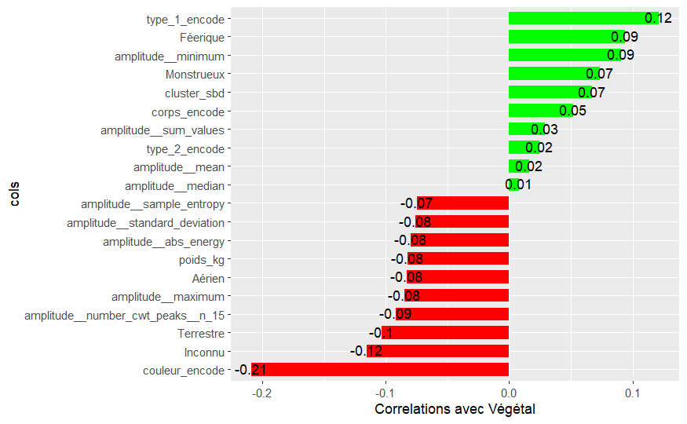

```r
Correlations(data_2,"Végétal")
```

2. Histogrammes de quelques variables

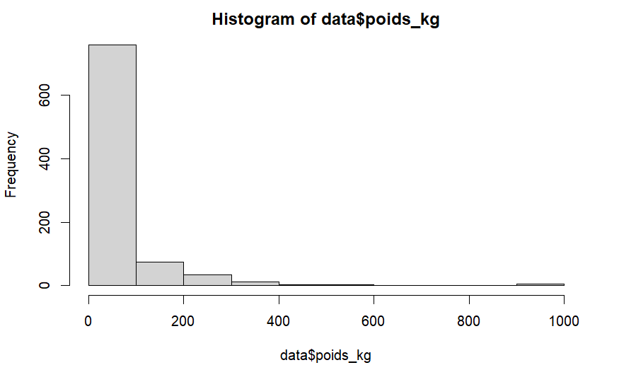

```r
hist(data$poids_kg)
```

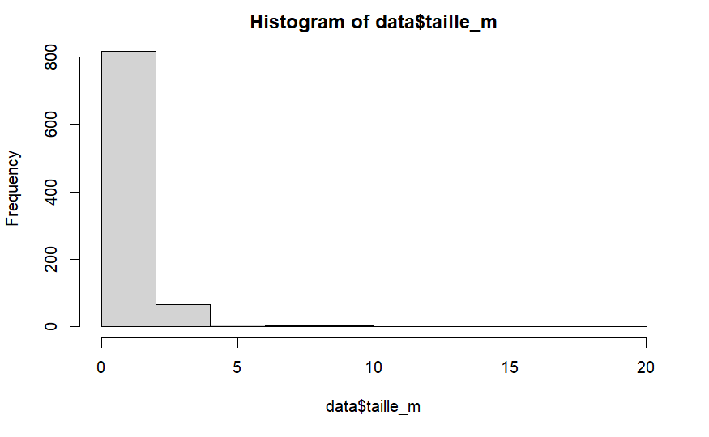

```r
hist(data$taille_m)
```

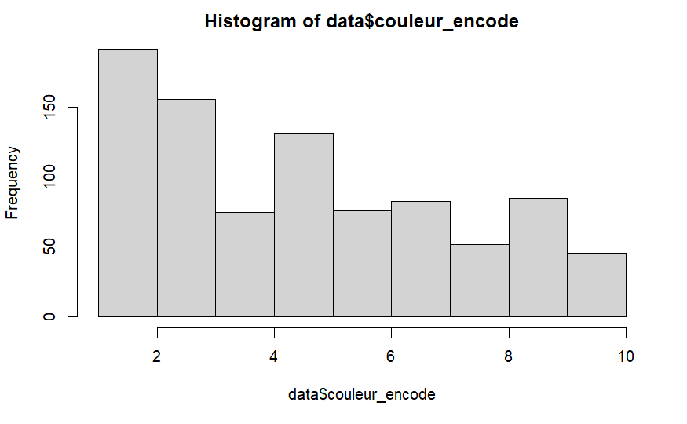

```r
hist(data$couleur_encode)
```

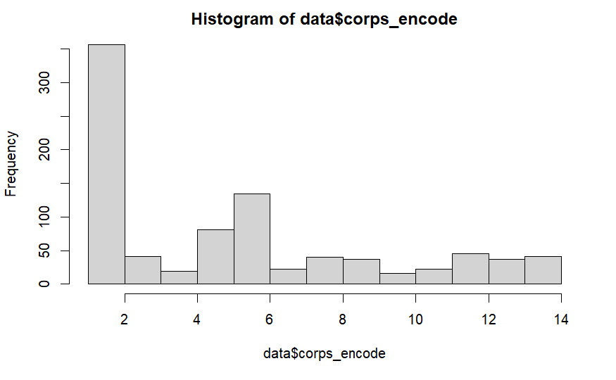

```r
hist(data$corps_encode)
```

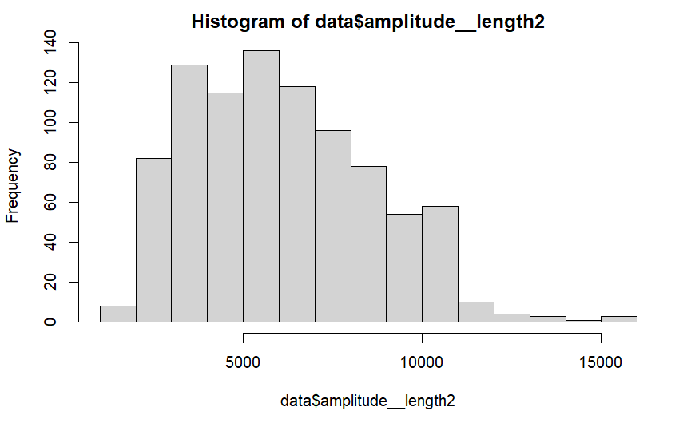

```r
hist(data$amplitude__length2)
```

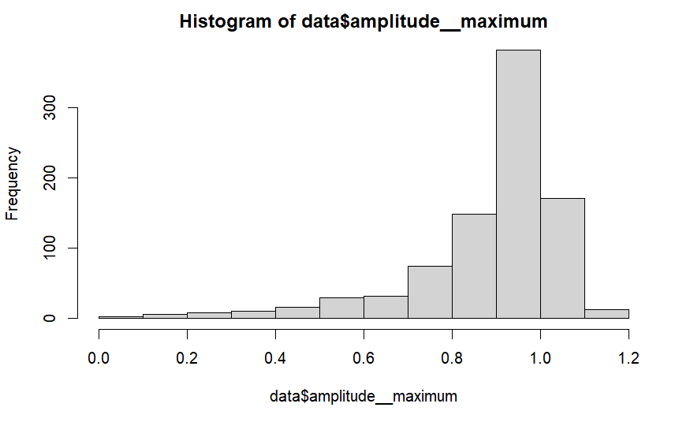

```r
hist(data$amplitude__maximum)
```

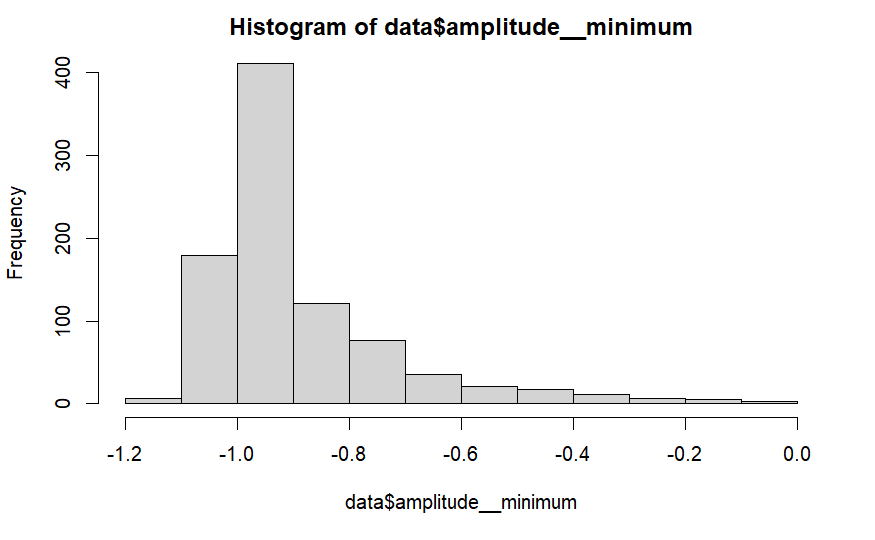

```r
hist(data$amplitude__minimum)
```

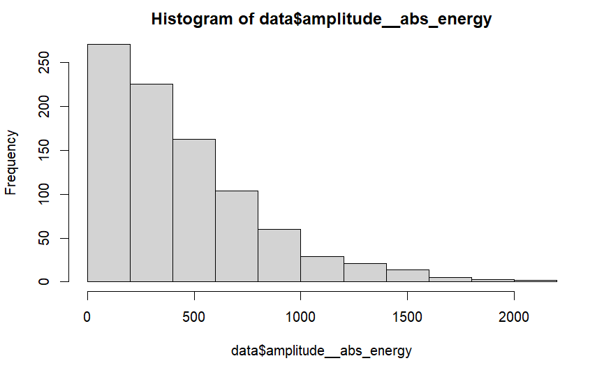

```r
hist(data$amplitude__abs_energy)
```

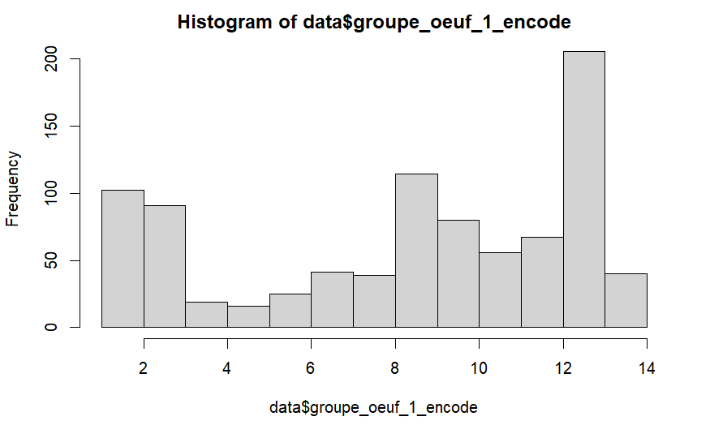

```r
hist(data$groupe_oeuf_1_encode)
```

3. Boxplots de quelques variables par rapport au la variable groupe_oeuf_1

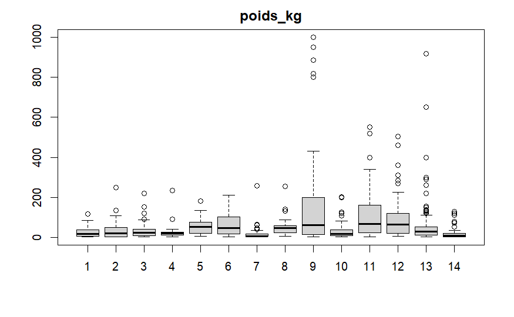

```r
boxplot(split(data$poids_kg,data$groupe_oeuf_1_encode), main="poids_kg")
```

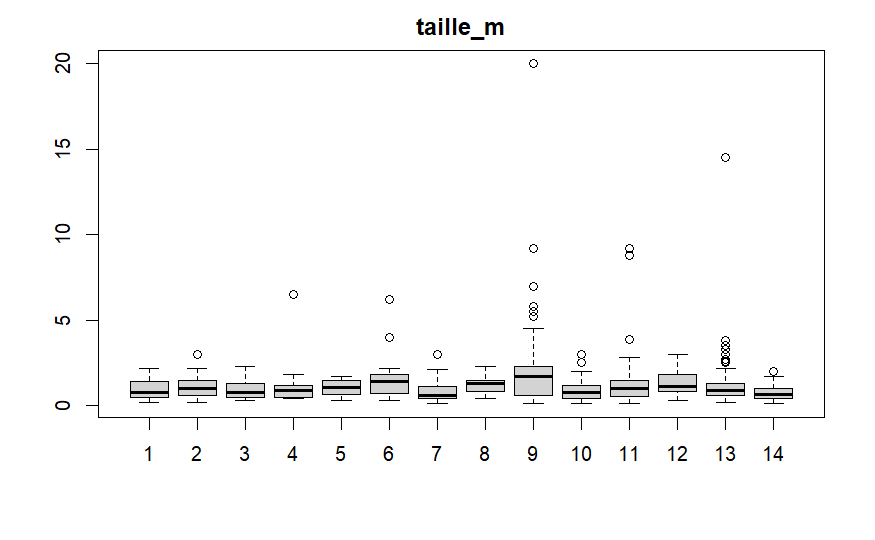

```r
boxplot(split(data$taille_m,data$groupe_oeuf_1_encode), main="taille_m")
```

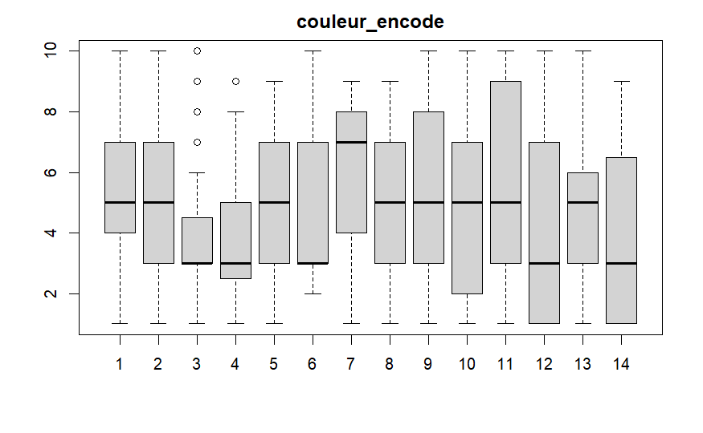

```r
boxplot(split(data$couleur_encode,data$groupe_oeuf_1_encode), main="couleur_encode")
```

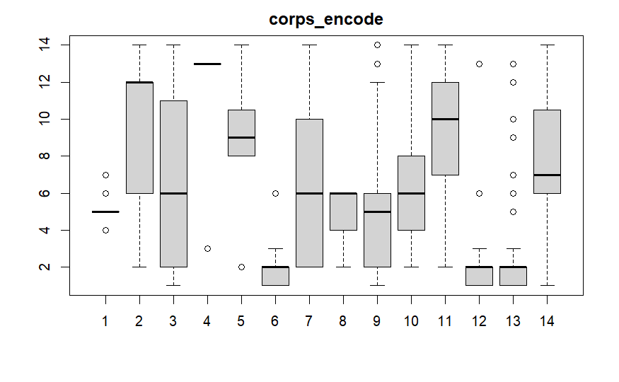

```r
boxplot(split(data$corps_encode,data$groupe_oeuf_1_encode), main="corps_encode")
```

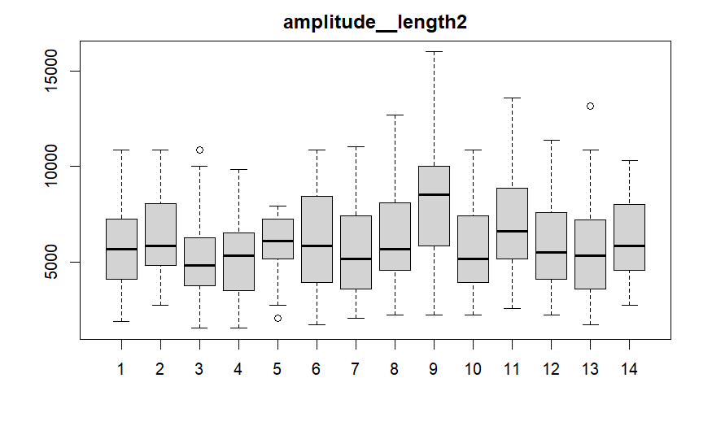

```r
boxplot(split(data$amplitude__length2,data$groupe_oeuf_1_encode), main="amplitude__length2")
```

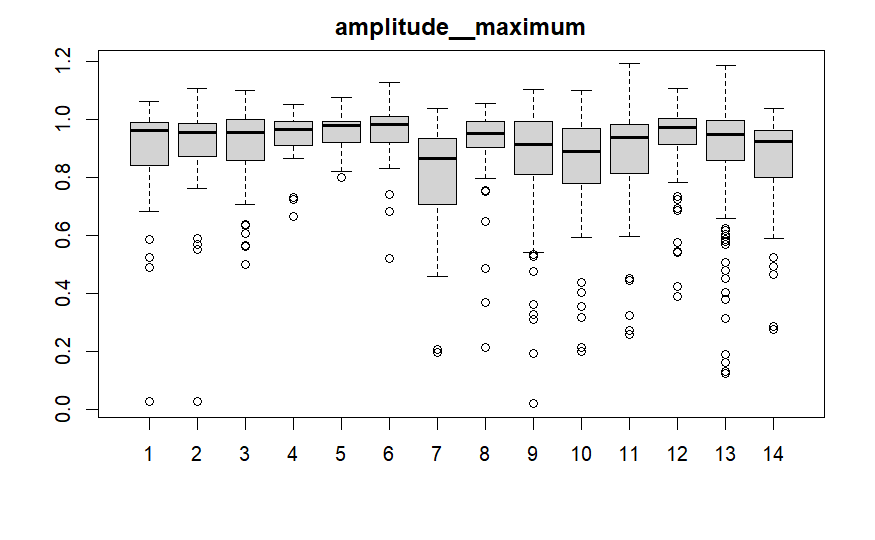

```r
boxplot(split(data$amplitude__maximum,data$groupe_oeuf_1_encode), main="amplitude__maximum")
```

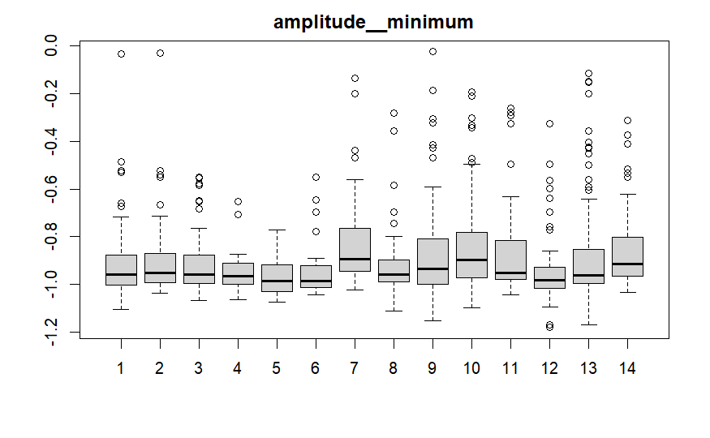

```r
boxplot(split(data$amplitude__minimum,data$groupe_oeuf_1_encode), main="amplitude__minimum")
```

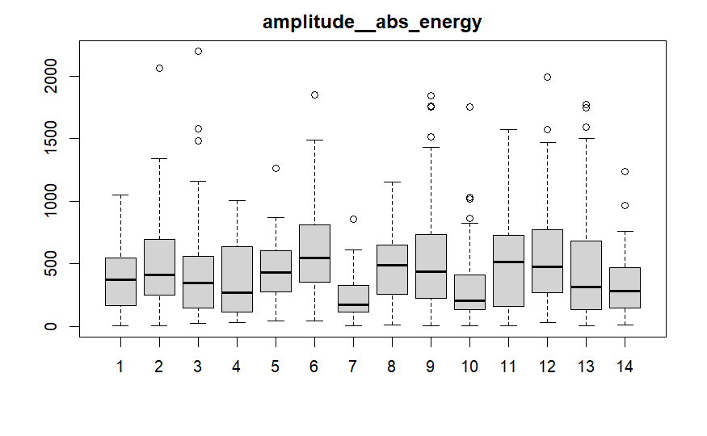

```r
boxplot(split(data$amplitude__abs_energy,data$groupe_oeuf_1_encode), main="amplitude__abs_energy")
```

4. Multiclass classification en utilisant un simple abre puis un random forest sur la variable groupe_oeuf_1_encode

4-1) Arbre unique avec Bootstrap

```r
précision_boot = matrix(0,nrow=100,ncol=1)
précision_max = 0
data_single_forecast = data[-c(28:41)] #Enlever colonnes avec tous les groupes d'oeufs
data_single_forecast = data_single_forecast[-c(1:2)] #Enlever colonnes avec url et nom
data_single_forecast$groupe_oeuf_1_encode = factor(data_single_forecast$groupe_oeuf_1_encode,     levels = c(1:14))

for (i in 1:100) {
  division_boot = sample(nrow(data_single_forecast), 0.6*nrow(data), replace = FALSE)
  TrainSet_boot = data_single_forecast[division_boot,]
  ValidSet_boot = data_single_forecast[-division_boot,]
  arbre_boot <- rpart(data_single_forecast$groupe_oeuf_1_encode~ ., data=data_single_forecast,subset = division_boot, control = rpart.control("minsplit" = 1), xval = 30)
  tab_boot = table(predict(arbre_boot, data_single_forecast[-division_boot,], type="class"), ValidSet_boot$groupe_oeuf_1_encode)
  précision_boot[i] = sum(diag(tab_boot))/sum(tab_boot)

  if (précision_boot[i] > précision_max) {
    précision_max = précision_boot[i]
    arbre_final = arbre_boot
    check = i
  }
}
```

4-1-1) Récupérer le meilleure arbre

```r
tab_final = table(predict(arbre_final, data_single_forecast[-division_boot,], type="class"), ValidSet_boot$groupe_oeuf_1_encode)
tab_final
```

```
      1  2  3  4  5  6  7  8  9 10 11 12 13 14
  1  15  1  0  0  0  0  0  0  0  0  1  0  0  0
  2   1 11  2  0  1  0  3  7  8  1  3  0  4  0
  3   0  0 22  0  3  0  0  0  3  0  0  2  2  0
  4   0  0  4  4  0  0  0  0  1  0  0  0  0  0
  5   0  0  0  0  0  0  0  0  0  0  0  0  0  0
  6   0  1  0  0  0  6  0  0  1  0  0  1  0  0
  7   0  4  3  0  0  0  4  0  3  1  3  0  2  1
  8   0  0  0  0  0  1  0  3  7  0  0  0  1  0
  9   3  0  3  0  0  0  0  1 13  0  0  2  5  0
  10  0  0  0  0  0  0  0  0  0 23  0  0  0  0
  11  1  1  1  0  0  0  0  0  4  0 14  0  0  0
  12  0  0  1  0  0  1  0  0  2  0  0  3  0  0
  13  0  0  2  0  1  0  4  3  8  1  0 13 75  1
  14  0  0  0  0  0  0  5  0  3  0  0  1  3 19
```

```r
sum(diag(tab_final))/sum(tab_final)
```

```
[1] 0.5921788
```

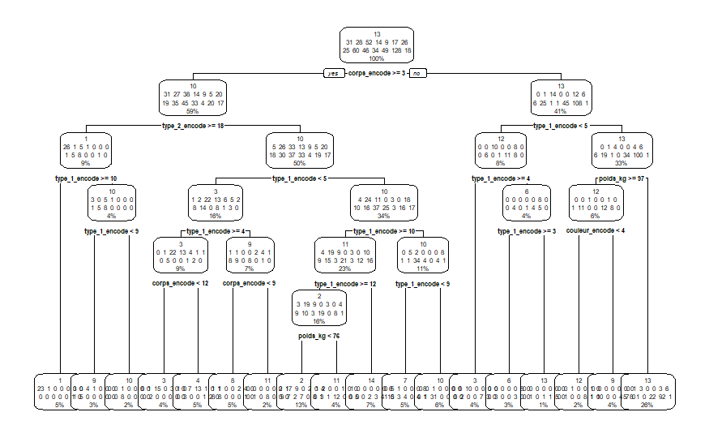

```r
rpart.plot(arbre_final,tweak=1.6,extra=101)
```

Le résultat dest de 60% de précision, ce qui est décent sans être exceptionnel

4-1-2) Moyenne et variance du bootstrap

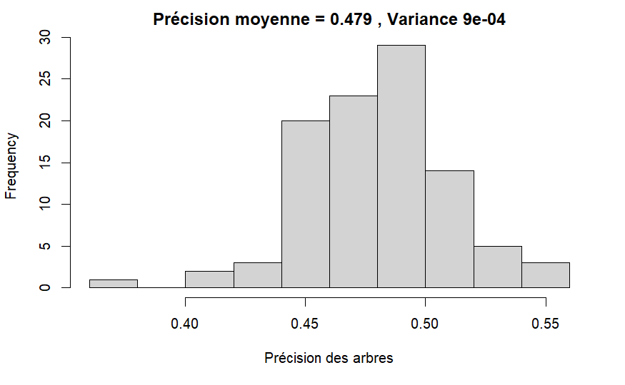

```r
hist(précision_boot,xlab="Précision des arbres",main=paste("Précision moyenne =",
                                                           round(mean(précision_boot),4),",",
                                                         "Variance",round(var(précision_boot),4)))
```

Cependant, la précision moyenne est seulement de 50%

4-2-1) Creation d’un RANDOM FOREST

```r
division_rf = sample(nrow(data_single_forecast), 0.7*nrow(data_single_forecast), replace = FALSE)
TrainSet_rf = data_single_forecast[division_rf,]
ValidSet_rf = data_single_forecast[-division_rf,]
```

4-2-2) Optimisation des paramètres avec grid search

```r
tgrid <- expand.grid(
  .mtry = 2:9,
  .splitrule = "gini",
  .min.node.size = 2:10)
```

4-2-3) Création du modèle

```r
rf = train(groupe_oeuf_1_encode  ~ ., data = TrainSet_rf,
           method = "ranger",
           trControl = trainControl(method="cv", number = 10, verboseIter = T, classProbs = F),
           tuneGrid = tgrid,
           num.trees = 100,
           importance = "impurity")
```

4-2-4) Test du modèle sur le set d’entrainement

```r
predTrain <- predict(rf, TrainSet_rf)
mean(predTrain == TrainSet_rf$groupe_oeuf_1_encode)
```

```
[1] 0.9952077
```

```r
table(predTrain, TrainSet_rf$groupe_oeuf_1_encode)
```

```
predTrain   1   2   3   4   5   6   7   8   9  10  11  12  13  14
       1   35   0   0   0   0   0   0   0   0   0   0   0   1   0
       2    0  36   0   0   0   0   0   0   0   0   0   0   0   0
       3    0   0  65   0   0   0   0   0   0   0   0   0   0   0
       4    0   0   0  12   0   0   0   0   0   0   0   0   0   0
       5    0   0   0   0  14   0   0   0   0   0   0   0   0   0
       6    0   0   0   0   0  21   0   0   0   0   0   0   0   0
       7    0   0   0   0   0   0  33   0   0   0   0   0   0   0
       8    0   0   0   0   0   0   0  30   0   0   0   0   0   0
       9    0   0   0   0   0   0   0   0  67   0   0   0   0   0
       10   0   0   0   0   0   0   0   0   0  56   0   0   0   0
       11   0   0   0   0   0   0   0   0   0   0  38   0   0   0
       12   0   0   0   0   0   0   0   0   0   0   0  50   0   0
       13   0   0   0   0   0   0   1   0   0   0   0   1 139   0
       14   0   0   0   0   0   0   0   0   0   0   0   0   0  27
```

4-2-5) Essai du modèle sur jeu de Test

```r
predValid <- predict(rf, ValidSet_rf)
mean(predValid == ValidSet_rf$groupe_oeuf_1_encode)
```

```
[1] 0.598513
```

```r
table(predValid,ValidSet_rf$groupe_oeuf_1_encode)
```

```
predValid  1  2  3  4  5  6  7  8  9 10 11 12 13 14
       1  17  0  1  0  0  0  0  0  1  2  0  0  1  0
       2   0  8  2  0  1  0  0  2  2  0  3  0  3  0
       3   2  1 13  5  1  0  1  0  2  0  1  0  2  0
       4   0  0  0  2  0  0  0  0  0  0  0  0  0  0
       5   0  0  0  0  0  0  0  0  0  0  0  0  0  0
       6   0  0  0  0  0  2  0  0  0  0  0  1  0  0
       7   0  0  0  0  0  0  3  0  3  0  2  0  0  0
       8   0  0  0  0  0  1  0  3  2  0  1  0  0  0
       9   0  0  1  0  0  0  0  1 15  0  1  3  4  0
       10  0  0  2  0  0  0  1  0  2 21  1  0  1  0
       11  0  1  2  0  0  0  1  0  4  0  7  0  0  0
       12  0  0  1  0  0  0  0  0  5  0  0  5  0  0
       13  1  1  4  0  0  1  1  3  8  1  0  7 53  1
       14  0  0  0  0  0  0  0  0  3  0  2  0  1 12
```

On arrive à 60% de précision, ce qui est similaire à l’arbre simple

5. Multilabel classification sur le groupe d’oeufs d’appartenance

5-1) Chargement et mise en forme des données pour constuire un modèle multilabel. On utilise le paramètre cc pour “CLASSIFIER CHAINS”, afin que les labels prédits soit utilisés au fur et à mesure par le modèle pour prédire les labels restants.

```r
#Create Train/Test
ds = data[-c(1:3)]
ds = mldr_from_dataframe(ds, labelIndices = c(25:38))
ds <- create_holdout_partition(ds, c(train=0.65, test=0.35), "iterative")
#Create  Classifier Chains multi-label method with the base algorithm Random Forest
brmodel <- cc(ds$train, "RF")
prediction <- predict(brmodel, ds$test)
```

5-2) Résultats sur set de test

```r
head(as.bipartition(prediction))
```

```
    Aérien Amorphe Aquatique 1 Aquatique 2 Aquatique 3 Draconique Féerique Humanoïde Inconnu
115      0       0           0           0           0          0        0         0       0
142      0       0           0           0           0          0        0         0       0
158      0       0           0           0           0          0        0         0       0
178      0       0           0           0           0          0        0         0       0
180      0       0           0           0           0          0        0         0       0
181      0       0           0           0           0          0        0         0       0
    Insectoïde Minéral Monstrueux Terrestre Végétal
115          0       0          0         1       0
142          0       0          0         1       0
158          0       0          0         1       0
178          0       0          0         1       0
180          0       0          0         1       0
181          0       0          0         0       1
```

5-3) Résultats en probabilité pour chaque label sur set de test

```r
head(as.probability(prediction))
```

```
    Aérien Amorphe Aquatique 1 Aquatique 2 Aquatique 3 Draconique Féerique Humanoïde Inconnu
115  0.010   0.030       0.102       0.002       0.030      0.064    0.004     0.042   0.070
142  0.080   0.094       0.166       0.012       0.030      0.090    0.254     0.084   0.362
158  0.042   0.016       0.382       0.044       0.028      0.118    0.008     0.150   0.088
178  0.010   0.012       0.084       0.008       0.038      0.080    0.152     0.012   0.130
180  0.006   0.024       0.008       0.000       0.000      0.000    0.022     0.044   0.020
181  0.022   0.016       0.060       0.006       0.018      0.010    0.148     0.062   0.146
    Insectoïde Minéral Monstrueux Terrestre Végétal
115      0.012   0.026      0.120     0.704   0.002
142      0.096   0.140      0.226     0.424   0.018
158      0.056   0.010      0.146     0.544   0.000
178      0.092   0.006      0.262     0.470   0.176
180      0.002   0.020      0.112     0.720   0.002
181      0.070   0.022      0.032     0.140   0.552
```

5-4) Classement des labels les plus probables pour chaque instance de test

```r
head(as.ranking(prediction))
```

```
    Aérien Amorphe Aquatique 1 Aquatique 2 Aquatique 3 Draconique Féerique Humanoïde Inconnu
115     11       7           3          13           7          5       12         6       4
142     11       8           5          14          12          9        3        10       2
158      9      11           2           8          10          5       13         3       6
178     12      10           7          13           9          8        4        10       5
180      9       4           8          12          12         12        5         3       6
181      9      12           7          14          11         13        2         6       3
    Insectoïde Minéral Monstrueux Terrestre Végétal
115         10       9          2         1      13
142          7       6          4         1      13
158          7      12          4         1      14
178          6      14          2         1       3
180         10       6          2         1      10
181          5       9          8         4       1
```

5-5) Garder seulement les 2 labels les plus probables

```r
newpred <- rcut_threshold(prediction, 2)
head(newpred)
```

```
    Aérien Amorphe Aquatique 1 Aquatique 2 Aquatique 3 Draconique Féerique Humanoïde Inconnu
115      0       0           0           0           0          0        0         0       0
142      0       0           0           0           0          0        0         0       1
158      0       0           1           0           0          0        0         0       0
178      0       0           0           0           0          0        0         0       0
180      0       0           0           0           0          0        0         0       0
181      0       0           0           0           0          0        1         0       0
    Insectoïde Minéral Monstrueux Terrestre Végétal
115          0       0          1         1       0
142          0       0          0         1       0
158          0       0          0         1       0
178          0       0          1         1       0
180          0       0          1         1       0
181          0       0          0         0       1
```

5-6) Comparaison sans/avec seuil à 2 labels

```r
result <- multilabel_evaluate(ds$tes, prediction, "bipartition")
thresres <- multilabel_evaluate(ds$tes, newpred, "bipartition")

round(cbind(Default=result, RCUT=thresres), 3)
```

```
                Default  RCUT
accuracy          0.543 0.431
F1                0.577 0.552
hamming-loss      0.072 0.104
macro-AUC         0.874 0.874
macro-F1          0.488 0.513
macro-precision   0.724 0.456
macro-recall      0.430 0.642
micro-AUC         0.891 0.891
micro-F1          0.565 0.558
micro-precision   0.644 0.459
micro-recall      0.504 0.709
precision         0.643 0.459
recall            0.545 0.737
subset-accuracy   0.442 0.097
```

Imposer un seuil ne samble pas particulièrement améliorer les performances

5-4) Resultats generaux

```r
result <- multilabel_evaluate(ds$tes, prediction, "bipartition", labels=TRUE)
result$labels
```

```
             accuracy       AUC    balacc         F1 precision     recall TP  TN FP FN
Aérien      0.9870130 0.9941990 0.9300699 0.90476190 0.9500000 0.86363636 19 285  1  3
Amorphe     0.9480519 0.9127261 0.6852497 0.50000000 0.7272727 0.38095238  8 284  3 13
Aquatique 1 0.9090909 0.8871048 0.7616436 0.60000000 0.6363636 0.56756757 21 259 12 16
Aquatique 2 0.9805195 0.9656262 0.7205500 0.57142857 0.8000000 0.44444444  4 298  1  5
Aquatique 3 0.9642857 0.7793082 0.5437710 0.15384615 0.5000000 0.09090909  1 296  1 10
Draconique  0.9285714 0.7684211 0.5217391 0.08333333 1.0000000 0.04347826  1 285  0 22
Féerique    0.9383117 0.7956695 0.6358885 0.38709677 0.6000000 0.28571429  6 283  4 15
Humanoïde   0.9448052 0.8132723 0.7103738 0.54054054 0.7142857 0.43478261 10 281  4 13
Inconnu     0.8798701 0.7482128 0.6791059 0.46376812 0.5333333 0.41025641 16 255 14 23
Insectoïde  0.9707792 0.9885675 0.8757261 0.83018868 0.9166667 0.75862069 22 277  2  7
Minéral     0.9220779 0.9065434 0.6525822 0.40000000 0.5000000 0.33333333  8 276  8 16
Monstrueux  0.9155844 0.8458546 0.5357143 0.13333333 1.0000000 0.07142857  2 280  0 26
Terrestre   0.7662338 0.8691075 0.7772889 0.65714286 0.5564516 0.80232558 69 167 55 17
Végétal     0.9415584 0.9652891 0.7585925 0.60869565 0.7000000 0.53846154 14 276  6 12
```

5-5) Evaluer model avec une matrice de confusion

```r
# Build a confusion matrix
confmat <- multilabel_confusion_matrix(ds$test, prediction)
result <- multilabel_evaluate(confmat)
print(confmat)
```

```
Multi-label Confusion Matrix

Absolute Matrix:
-------------------------------------
             Expected_1 Expected_0 TOTAL
Prediction_1        201        111   312
Predicion_0         198       3802  4000
TOTAL               399       3913  4312

Proportinal Matrix:
-------------------------------------
             Expected_1 Expected_0 TOTAL
Prediction_1      0.047      0.026 0.072
Predicion_0       0.046      0.882 0.928
TOTAL             0.093      0.907 1.000

Label Matrix
-------------------------------------
```

|  | TP | FP | FN | TN | Correct | Wrong | %TP | %FP | %FN | %TN | %Correct | %Wrong | MeanRanking | MeanScore |
| --- | --- | --- | --- | --- | --- | --- | --- | --- | --- | --- | --- | --- | --- | --- |
| Aérien | 19 | 1 | 3 | 285 | 304 | 4 | 0.06 | 0.00 | 0.01 | 0.93 | 0.99 | 0.01 | 10.09 | 0.07 |
| Amorphe | 8 | 3 | 13 | 284 | 292 | 16 | 0.03 | 0.01 | 0.04 | 0.92 | 0.95 | 0.05 | 7.81 | 0.08 |
| Aquatique 1 | 21 | 12 | 16 | 259 | 280 | 28 | 0.07 | 0.04 | 0.05 | 0.84 | 0.91 | 0.09 | 6.77 | 0.13 |
| Aquatique 2 | 4 | 1 | 5 | 298 | 302 | 6 | 0.01 | 0.00 | 0.02 | 0.97 | 0.98 | 0.02 | 11.98 | 0.03 |
| Aquatique 3 | 1 | 1 | 10 | 296 | 297 | 11 | 0.00 | 0.00 | 0.03 | 0.96 | 0.96 | 0.04 | 9.80 | 0.04 |
| Draconique | 1 | 0 | 22 | 285 | 286 | 22 | 0.00 | 0.00 | 0.07 | 0.93 | 0.93 | 0.07 | 7.34 | 0.08 |
| Féerique | 6 | 4 | 15 | 283 | 289 | 19 | 0.02 | 0.01 | 0.05 | 0.92 | 0.94 | 0.06 | 6.98 | 0.09 |
| Humanoïde | 10 | 4 | 13 | 281 | 291 | 17 | 0.03 | 0.01 | 0.04 | 0.91 | 0.94 | 0.06 | 6.30 | 0.10 |
| Inconnu | 16 | 14 | 23 | 255 | 271 | 37 | 0.05 | 0.05 | 0.07 | 0.83 | 0.88 | 0.12 | 5.34 | 0.14 |
| Insectoïde | 22 | 2 | 7 | 277 | 299 | 9 | 0.07 | 0.01 | 0.02 | 0.90 | 0.97 | 0.03 | 6.46 | 0.10 |

[output cut: 4 more lines]

5-6) Synthetiser les resultats